# Text analysis

[<<BACK](https://remi-daigle.github.io/2017-CHONe-Data/)

# Text analysis in R

To begin, we wish to credit Julia Silge for much of the material presented here. Her [post](http://juliasilge.com/blog/Life-Changing-Magic/) on `tidytext` data analysis and the code therein inspired most of this portion of the workshop.

## Selecting a text to analyze for the workshop

Let’s begin by downloading two documents written by our dear Dr. Paul Snelgrove. The first one is his book entitled [‘Discoveries of the Census of Marine Life: Making Ocean Life Count’](http://www.cambridge.org/download_file/153663) and the second is one of his most cited paper (*n* = 886) according to google scholar, Getting to the Bottom of Marine Biodiversity: Sedimentary Habitats: Ocean bottoms are the most widespread habitat on Earth and support high biodiversity and key ecosystem services.

```r
    # Download file from the web
        download.file('http://www.cambridge.org/download_file/153663','Snelgrove_Text_Only.pdf', mode = 'wb')

        download.file('https://oup.silverchair-cdn.com/oup/backfile/Content_public/Journal/bioscience/49/2/10.2307/1313538/2/49-2-129.pdf?Expires=1493740003&Signature=Jp0aTSea-mCne3vgy6tE2JYz58l-K4iWPF3gnd8r-GagpywgUq8U9WcImKsSa~bDZOj5mY3216xNoqSDWXGLBdumI-WIRvUrHFKj1AetoS-Rsyup0NVO9nWE0te8dsIYDWEKkUXvu7-9xdHnmpa5QSNUlE8kM8V~4B68mdJR7W0eE-at~GH4p7IrPRDeAN9n8U~I2Kd-s~KkYgAV6ASxvzXhK4sLUaja~xs3n5eXdhTrcaJINFOxk2~2nU17jDgXM6PUw3W5Epvdywz4s6~eU4IyWCst4sokZAV3OczO7NiagYdKq3foTi~Y-EP~c0uvPr1gRFoxT6itFNGSSZCk6A__&Key-Pair-Id=APKAIUCZBIA4LVPAVW3Q/', '49-2-129.pdf', mode = 'wd')
```

## Importing text from pdfs in R

The package [`pdftools`](https://ropensci.org/blog/blog/2016/03/01/pdftools-and-jeroen) allows you to read the content of a pdf rather easily and is available on ROpenSci. See package details for more functions

```r
    # Read pdf file
        book <- pdf_text("Snelgrove_Text_Only.pdf")
        paper <- pdf_text("49-2-129.pdf")

        book[1]
```

```
## [1] "     Discoveries of the Census of Marine Life:\n                 Making Ocean Life Count\nOver the 10-year course of the recently completed Census of Marine Life,\na global network of researchers in more than 80 nations has collaborated\nto improve our understanding of marine biodiversity – …
```

```r
        length(book)
```

```
## [1] 398
```

```r
        paper[1]
```

```
## [1] "      Getting to the Bottom of Marine\n Biodiversity:                                   Sedimentary                                 Habitats\n       Oceanbottomsare the most widespreadhabitaton Earthand\n                support high biodiversityand key ecosystemservices\n                    …
```

```r
        length(paper)
```

```
## [1] 10
```

As you can see, the resulting book is coerced as a page per string for a total of 398 pages, while there are 10 pages for the paper, with lines divided by ‘\n’. If you look at the actual pdf, you will also realize that tables are not imported in R using the `pdf_text` function. This could be highly useful to get data embedded in pdf format. If you wish do so, you can take a look at the package [`tabulizer`](https://ropensci.org/blog/blog/2017/04/18/tabulizer), which we will not cover in this workshop.

Now let’s tidy up the text to make it more easily usable for further analyses.

## Tidy up text

```r
    # Divide strings per line using '\n as a separator'
        book <- str_split(book, '\n')
        paper <- str_split(paper, '\n')
        book[[1]][1:10]
```

```
##  [1] "     Discoveries of the Census of Marine Life:"
##  [2] "                 Making Ocean Life Count"
##  [3] "Over the 10-year course of the recently completed Census of Marine Life,"
##  [4] "a global network of researchers in more than 80 nations has collaborated"
##  [5] "to improve our understanding of marine biodiversity – past, present, and"
##  [6] "future."
##  [7] "        Providing insight into this remarkable project, this book explains"
##  [8] "the rationale behind the Census and highlights some of its most important"
##  [9] "and dramatic findings, illustrated with full-color photographs throughout."
## [10] "It explores how new technologies and partnerships have contributed to"
```

```r
    # Trim whitespaces at the beginning and end of lines
        book <- lapply(X = book, FUN = str_trim, side = 'both')
        paper <- lapply(X = paper, FUN = str_trim, side = 'both')
        book[[1]][1:10]
```

```
##  [1] "Discoveries of the Census of Marine Life:"
##  [2] "Making Ocean Life Count"
##  [3] "Over the 10-year course of the recently completed Census of Marine Life,"
##  [4] "a global network of researchers in more than 80 nations has collaborated"
##  [5] "to improve our understanding of marine biodiversity – past, present, and"
##  [6] "future."
##  [7] "Providing insight into this remarkable project, this book explains"
##  [8] "the rationale behind the Census and highlights some of its most important"
##  [9] "and dramatic findings, illustrated with full-color photographs throughout."
## [10] "It explores how new technologies and partnerships have contributed to"
```

```r
    # Transform as a matrix
        bookMat <- matrix(nrow = 0, ncol = 3, dimnames = list(c(), c('text','page','document')))
        for(i in 1:length(book)) {
            bk <- cbind(book[[i]], rep(i, length(book[[i]])), 'Discoveries of the Census of Marine Life')
            bookMat <- rbind(bookMat, bk)
        }

        paperMat <- matrix(nrow = 0, ncol = 3, dimnames = list(c(), c('text','page','document')))
        for(i in 1:length(paper)) {
            bk <- cbind(paper[[i]], rep(i, length(paper[[i]])), 'Getting to the Bottom of Marine Biodiversity')
            paperMat <- rbind(paperMat, bk)
        }

        kable(bookMat[1:10, ])
```

| text | page | document |
| --- | --- | --- |
| Discoveries of the Census of Marine Life: | 1 | Discoveries of the Census of Marine Life |
| Making Ocean Life Count | 1 | Discoveries of the Census of Marine Life |
| Over the 10-year course of the recently completed Census of Marine Life, | 1 | Discoveries of the Census of Marine Life |
| a global network of researchers in more than 80 nations has collaborated | 1 | Discoveries of the Census of Marine Life |
| to improve our understanding of marine biodiversity – past, present, and | 1 | Discoveries of the Census of Marine Life |
| future. | 1 | Discoveries of the Census of Marine Life |
| Providing insight into this remarkable project, this book explains | 1 | Discoveries of the Census of Marine Life |
| the rationale behind the Census and highlights some of its most important | 1 | Discoveries of the Census of Marine Life |
| and dramatic findings, illustrated with full-color photographs throughout. | 1 | Discoveries of the Census of Marine Life |
| It explores how new technologies and partnerships have contributed to | 1 | Discoveries of the Census of Marine Life |

```r
    # Remove empty strings
        bookMat[bookMat[,'text'] == '', 'text'] <- NA
        bookMat <- na.omit(bookMat)

        paperMat[paperMat[,'text'] == '', 'text'] <- NA
        paperMat <- na.omit(paperMat)

    # Convert to data.frame
        bookMat <- as.data.frame(bookMat)
        bookMat[, 'text'] <- as.character(bookMat[, 'text'])
        bookMat[, 'page'] <- as.numeric(paste(bookMat[, 'page']))
        bookMat[, 'document'] <- as.character(paste(bookMat[, 'document']))
        kable(bookMat[1:10, ])
```

| text | page | document |
| --- | --- | --- |
| Discoveries of the Census of Marine Life: | 1 | Discoveries of the Census of Marine Life |
| Making Ocean Life Count | 1 | Discoveries of the Census of Marine Life |
| Over the 10-year course of the recently completed Census of Marine Life, | 1 | Discoveries of the Census of Marine Life |
| a global network of researchers in more than 80 nations has collaborated | 1 | Discoveries of the Census of Marine Life |
| to improve our understanding of marine biodiversity – past, present, and | 1 | Discoveries of the Census of Marine Life |
| future. | 1 | Discoveries of the Census of Marine Life |
| Providing insight into this remarkable project, this book explains | 1 | Discoveries of the Census of Marine Life |
| the rationale behind the Census and highlights some of its most important | 1 | Discoveries of the Census of Marine Life |
| and dramatic findings, illustrated with full-color photographs throughout. | 1 | Discoveries of the Census of Marine Life |
| It explores how new technologies and partnerships have contributed to | 1 | Discoveries of the Census of Marine Life |

```r
        paperMat <- as.data.frame(paperMat)
        paperMat[, 'text'] <- as.character(paperMat[, 'text'])
        paperMat[, 'page'] <- as.numeric(paste(paperMat[, 'page']))
        paperMat[, 'document'] <- as.character(paste(paperMat[, 'document']))
        kable(paperMat[1:10, ])
```

| text | page | document |
| --- | --- | --- |
| Getting to the Bottom of Marine | 1 | Getting to the Bottom of Marine Biodiversity |
| Biodiversity: Sedimentary Habitats | 1 | Getting to the Bottom of Marine Biodiversity |
| Oceanbottomsare the most widespreadhabitaton Earthand | 1 | Getting to the Bottom of Marine Biodiversity |
| support high biodiversityand key ecosystemservices | 1 | Getting to the Bottom of Marine Biodiversity |
| Paul V. R. Snelgrove | 1 | Getting to the Bottom of Marine Biodiversity |
| T heoceansencompasshabitats I | 1 | Getting to the Bottom of Marine Biodiversity |
| Living in marine sediments | 1 | Getting to the Bottom of Marine Biodiversity |
| ranging from highly produc- | 1 | Getting to the Bottom of Marine Biodiversity |
| tive coastal regions to lightless, Estimates of total Organisms that live in marine sedi- | 1 | Getting to the Bottom of Marine Biodiversity |
| ments face numerous challenges. | 1 | Getting to the Bottom of Marine Biodiversity |

```r
    # bind as a single data.framt
        paul <- rbind(bookMat, paperMat)
```

The resulting data for the paper are not perfect (*i.e.* truncated words are not regrouped), but they will serve for our purposes!

## Text analysis

Now that we have our document as a R data frame, we can start playing around with it. There are multiple packages that allow you perform text analyses. We will focus on package `tidytext` as it aligns with the tidyverse, but the package `tm` is another important package used to perform text analysis under R. Each package uses certain classes of object, but classes can be modified quite easily for use between the packages. See this [vignette](http://127.0.0.1:15641/library/tidytext/doc/tidying_casting.html) for a description of steps and functions used to achieve this.

We will first transform the book as a [tibble class object](https://www.rdocumentation.org/packages/tibble/versions/1.2) for use in `tidytext`

```r
    # Convert to tibble class object for use in tidytext
        paul <- as_tibble(paul)
        paul
```

```
## # A tibble: 8,824 × 3
##                                                                          text
## *                                                                       <chr>
## 1                                   Discoveries of the Census of Marine Life:
## 2                                                     Making Ocean Life Count
## 3    Over the 10-year course of the recently completed Census of Marine Life,
## 4    a global network of researchers in more than 80 nations has collaborated
## 5    to improve our understanding of marine biodiversity – past, present, and
## 6                                                                     future.
## 7          Providing insight into this remarkable project, this book explains
## 8   the rationale behind the Census and highlights some of its most important
## 9  and dramatic findings, illustrated with full-color photographs throughout.
## 10      It explores how new technologies and partnerships have contributed to
## # ... with 8,814 more rows, and 2 more variables: page <dbl>,
## #   document <chr>
```

### Group your text by attributes

The book can easily be grouped by certain criterion. For exemple, we will start by grouping the data according to which part of the book they belong. There are a total of three parts to this book. Unfortunately, this particular process does not work for our pdf document, but the code does work we might use it again elsewhere, let’s say for an exercice (*cough cough*).

```r
    paulDoc <- paul %>%
                    mutate(linenumber = row_number(),
                           chapter  = cumsum(str_detect(text, regex("^part [\\divxlc]", ignore_case = TRUE)))) %>%
                    ungroup()

    paulDoc
```

```
## # A tibble: 8,824 × 5
##                                                                          text
##                                                                         <chr>
## 1                                   Discoveries of the Census of Marine Life:
## 2                                                     Making Ocean Life Count
## 3    Over the 10-year course of the recently completed Census of Marine Life,
## 4    a global network of researchers in more than 80 nations has collaborated
## 5    to improve our understanding of marine biodiversity – past, present, and
## 6                                                                     future.
## 7          Providing insight into this remarkable project, this book explains
## 8   the rationale behind the Census and highlights some of its most important
## 9  and dramatic findings, illustrated with full-color photographs throughout.
## 10      It explores how new technologies and partnerships have contributed to
## # ... with 8,814 more rows, and 4 more variables: page <dbl>,
## #   document <chr>, linenumber <int>, chapter <int>
```

```r
    unique(paulDoc[, 'chapter'])
```

```
## # A tibble: 4 × 1
##   chapter
##     <int>
## 1       0
## 2       1
## 3       2
## 4       3
```

This function is not useful with these documents as they are not divided by chapters and the function does not differentiate between documents, yet the regex code can still be useful to divide your text however you may see fit.

### Term frequency

A frequent analysis performed with text is to evaluate the frequency of words used in the text. This can be done by first unnesting the individual words from the text with the `unnest_tokens` function and using the `count` function to count the number of words.

```r
    # Count per word
        paulWord <- paul %>%
                        unnest_tokens(word, text) %>% # divide by word
                        count(word, sort = TRUE) # counts the word frequency
        paulWord
```

```
## # A tibble: 12,159 × 2
##       word     n
##      <chr> <int>
## 1      the  3524
## 2      and  3330
## 3       of  2582
## 4       in  1784
## 5        a  1452
## 6       to  1094
## 7  species   730
## 8        j   725
## 9      sea   583
## 10   ocean   548
## # ... with 12,149 more rows
```

```r
    # Total number of words
        totalWords <- paulWord %>% summarize(total = sum(n))
        totalWords
```

```
## # A tibble: 1 × 1
##   total
##   <int>
## 1 85305
```

You could also apply this directly to the data grouped by chapters to obtain a word count per chapters.

```r
    # Count per word per chapter
        paulWordDocs <- paul %>%
                            mutate(linenumber = row_number()) %>%
                            ungroup() %>%
                            unnest_tokens(word, text) %>%
                            count(document, word, sort = TRUE) %>%
                            ungroup()

    # Attach total number of words per chapter
        totalWords <- paulWordDocs %>% group_by(document) %>% summarize(total = sum(n))
        totalWords
```

```
## # A tibble: 2 × 2
##                                       document total
##                                          <chr> <int>
## 1     Discoveries of the Census of Marine Life 76913
## 2 Getting to the Bottom of Marine Biodiversity  8392
```

```r
        paulWordDocs <- left_join(paulWordDocs, totalWords)
        paulWordDocs
```

```
## # A tibble: 13,707 × 4
##                                    document    word     n total
##                                       <chr>   <chr> <int> <int>
## 1  Discoveries of the Census of Marine Life     the  3237 76913
## 2  Discoveries of the Census of Marine Life     and  3025 76913
## 3  Discoveries of the Census of Marine Life      of  2315 76913
## 4  Discoveries of the Census of Marine Life      in  1578 76913
## 5  Discoveries of the Census of Marine Life       a  1361 76913
## 6  Discoveries of the Census of Marine Life      to   957 76913
## 7  Discoveries of the Census of Marine Life       j   719 76913
## 8  Discoveries of the Census of Marine Life species   642 76913
## 9  Discoveries of the Census of Marine Life     sea   540 76913
## 10 Discoveries of the Census of Marine Life   ocean   536 76913
## # ... with 13,697 more rows
```

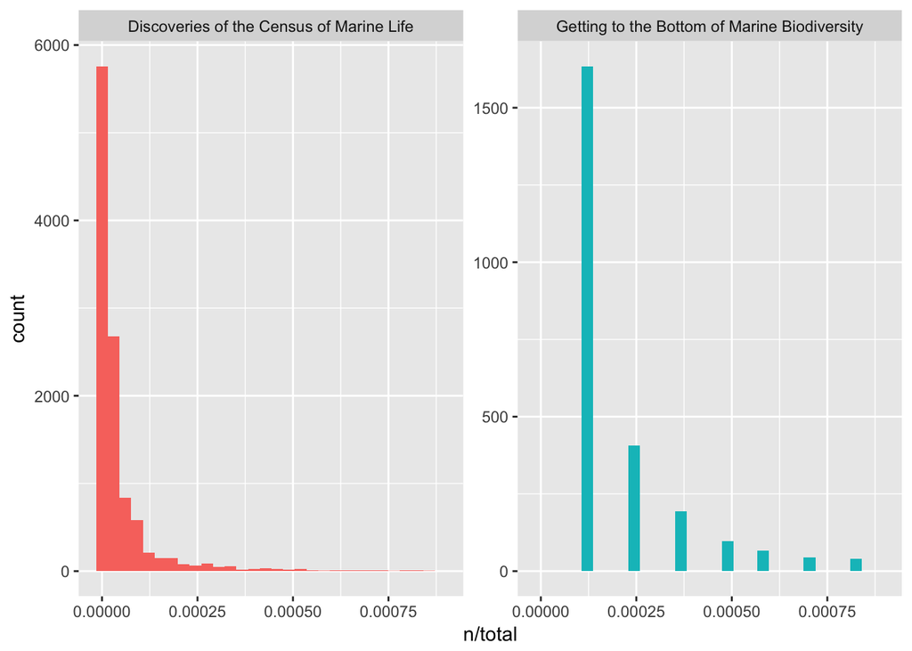

```r
        ggplot(paulWordDocs, aes(n/total, fill = document)) +
          geom_histogram(show.legend = FALSE) +
          xlim(NA, 0.0009) +
          facet_wrap(~document, ncol = 2, scales = "free_y")
```

Words like ‘the’, ‘and’, ‘of’ are the most common by far. Those are referred to as *stop words* and are usually removed in text analysis. A list of such words is available in the `stop_words` dataset and can be removed from your dataset using function `anti_join`.

```r
    # Count per word after stop words removal
        data("stop_words")
        paulWordDocs <- paul %>%
                            mutate(linenumber = row_number()) %>%
                            ungroup() %>%
                            unnest_tokens(word, text) %>%
                            anti_join(stop_words) %>% # remove stop words
                            count(document, word, sort = TRUE) %>%
                            ungroup()
        totalWords <- paulWordDocs %>% group_by(document) %>% summarize(total = sum(n))
        paulWordDocs <- left_join(paulWordDocs, totalWords)
        paulWordDocs
```

```
## # A tibble: 12,916 × 4
##                                    document         word     n total
##                                       <chr>        <chr> <int> <int>
## 1  Discoveries of the Census of Marine Life      species   642 46796
## 2  Discoveries of the Census of Marine Life          sea   540 46796
## 3  Discoveries of the Census of Marine Life        ocean   536 46796
## 4  Discoveries of the Census of Marine Life         deep   474 46796
## 5  Discoveries of the Census of Marine Life       marine   390 46796
## 6  Discoveries of the Census of Marine Life    diversity   308 46796
## 7  Discoveries of the Census of Marine Life           al   291 46796
## 8  Discoveries of the Census of Marine Life         life   229 46796
## 9  Discoveries of the Census of Marine Life         fish   225 46796
## 10 Discoveries of the Census of Marine Life biodiversity   198 46796
## # ... with 12,906 more rows
```

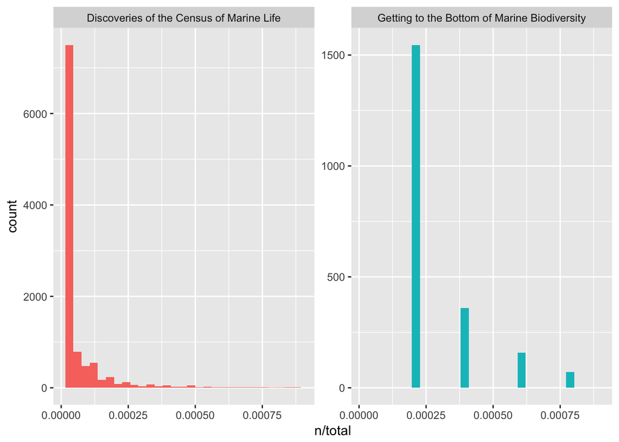

```r
        ggplot(paulWordDocs, aes(n/total, fill = document)) +
          geom_histogram(show.legend = FALSE) +
          xlim(NA, 0.0009) +
          facet_wrap(~document, ncol = 2, scales = "free_y")
```

### Word frequency comparison

The frequency of words could also be compared between documents.

```r
    paulBook <- as_tibble(bookMat)
    paulPaper <- as_tibble(paperMat)

    paulBookWord <- paulBook %>%
                        mutate(linenumber = row_number()) %>%
                        ungroup() %>%
                        unnest_tokens(word, text) %>%
                        anti_join(stop_words) %>% # remove stop words
                        count(word, sort = TRUE) %>%

                        ungroup()
    paulPaperWord <- paulPaper %>%
                        mutate(linenumber = row_number()) %>%
                        ungroup() %>%
                        unnest_tokens(word, text) %>%
                        anti_join(stop_words) %>% # remove stop words
                        count(word, sort = TRUE) %>%
                        ungroup()
    frequency <- paulBookWord %>%
                    rename(Book = n) %>%
                    inner_join(paulPaperWord) %>%
                    rename(Paper = n) %>%
                    mutate(Book = Book / sum(Book),
                           Paper = Paper / sum(Paper)) %>%
                    ungroup()
```

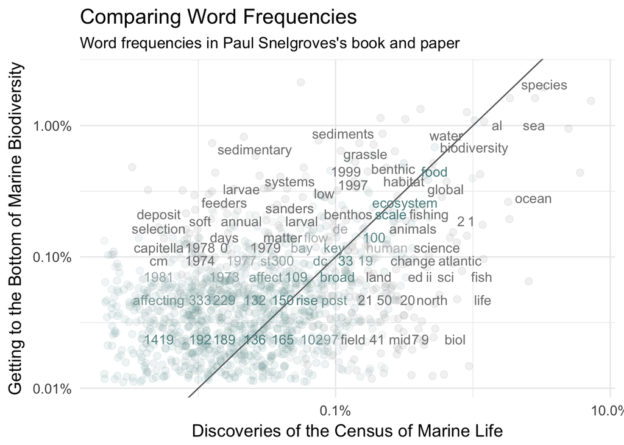

```r
    ggplot(frequency, aes(x = Book, y = Paper, color = abs(Paper - Book))) +
            geom_abline(color = "gray40") +
            geom_jitter(alpha = 0.1, size = 2.5, width = 0.4, height = 0.4) +
            geom_text(aes(label = word), check_overlap = TRUE, vjust = 1.5) +
            scale_x_log10(labels = percent_format()) +
            scale_y_log10(labels = percent_format()) +
            scale_color_gradient(limits = c(0, 0.001), low = "darkslategray4", high = "gray75") +
            theme_minimal(base_size = 14) +
            theme(legend.position="none") +
            labs(title = "Comparing Word Frequencies",
                 subtitle = "Word frequencies in Paul Snelgroves's book and paper",
                 y = "Getting to the Bottom of Marine Biodiversity", x = "Discoveries of the Census of Marine Life")
```

### Sentiment analysis

`tidytext` also gives the opportunity to perform a cursory sentiment analysis, *i.e.* evaluating whether the text is more or less negative, using the `sentiment` dataset. While it may not be as useful to qualify positive or negative science, it may reveal some insights as to the overall style of writing of the author (we are looking at you Dr. Snelgrove).

```r
    # Gather list of sentiments from tidytext
        bing <- sentiments %>%
                filter(lexicon == "bing") %>%
                dplyr::select(-score)
        bing
```

```
## # A tibble: 6,788 × 3
##           word sentiment lexicon
##          <chr>     <chr>   <chr>
## 1      2-faced  negative    bing
## 2      2-faces  negative    bing
## 3           a+  positive    bing
## 4     abnormal  negative    bing
## 5      abolish  negative    bing
## 6   abominable  negative    bing
## 7   abominably  negative    bing
## 8    abominate  negative    bing
## 9  abomination  negative    bing
## 10       abort  negative    bing
## # ... with 6,778 more rows
```

```r
        paulSentiment <- paul %>%
                            mutate(linenumber = row_number()) %>%
                            ungroup() %>%
                            unnest_tokens(word, text) %>%
                            anti_join(stop_words) %>% # remove stop words
                            inner_join(bing) %>% # join with sentiment dataset
                            count(document, index = linenumber %/% 80, sentiment) %>%
                            spread(sentiment, n, fill = 0) %>%
                            mutate(sentiment = positive - negative)
        paulSentiment
```

```
## Source: local data frame [112 x 5]
## Groups: document, index [112]
##
##                                    document index negative positive
##                                       <chr> <dbl>    <dbl>    <dbl>
## 1  Discoveries of the Census of Marine Life     0        3        6
## 2  Discoveries of the Census of Marine Life     1       18        9
## 3  Discoveries of the Census of Marine Life     2       13       24
## 4  Discoveries of the Census of Marine Life     3        3       21
## 5  Discoveries of the Census of Marine Life     4        7       32
## 6  Discoveries of the Census of Marine Life     5       13       16
## 7  Discoveries of the Census of Marine Life     6       12       10
## 8  Discoveries of the Census of Marine Life     7        9       16
## 9  Discoveries of the Census of Marine Life     8        9       10
## 10 Discoveries of the Census of Marine Life     9        7        4
## # ... with 102 more rows, and 1 more variables: sentiment <dbl>
```

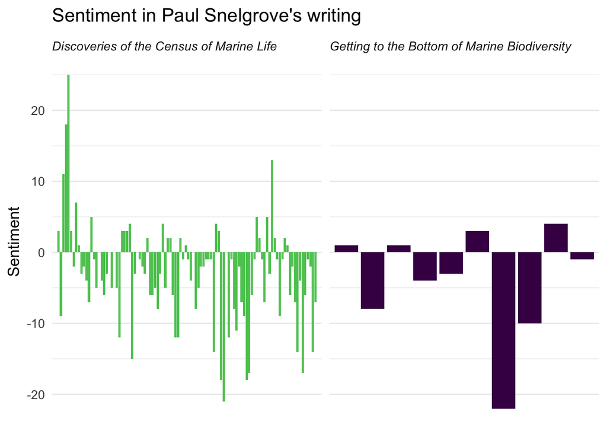

```r
        # plot
            ggplot(paulSentiment, aes(index, sentiment, fill = document)) +
                    geom_bar(stat = "identity", show.legend = FALSE) +
                    facet_wrap(~document, ncol = 2, scales = "free_x") +
                    theme_minimal(base_size = 13) +
                    labs(title = "Sentiment in Paul Snelgrove's writing",
                         y = "Sentiment") +
                    scale_fill_viridis(end = 0.75, discrete=TRUE, direction = -1) +
                    scale_x_discrete(expand=c(0.02,0)) +
                    theme(strip.text=element_text(hjust=0)) +
                    theme(strip.text = element_text(face = "italic")) +
                    theme(axis.title.x=element_blank()) +
                    theme(axis.ticks.x=element_blank()) +
                    theme(axis.text.x=element_blank())
```

```r
        # Most common positive and negative words
        paulSentimentCount <- paul %>%
                                mutate(linenumber = row_number()) %>%
                                ungroup() %>%
                                unnest_tokens(word, text) %>%
                                anti_join(stop_words) %>% # remove stop words
                                inner_join(bing) %>% # join with sentiment dataset
                                count(document, word, sentiment, sort = TRUE) %>%
                                ungroup()
```

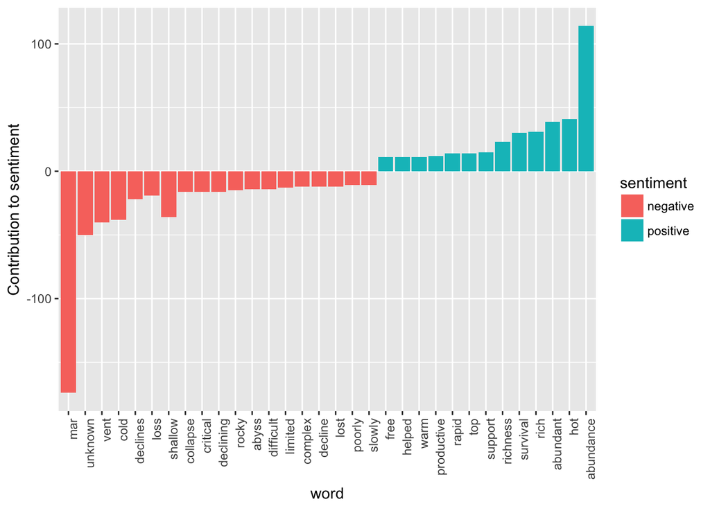

```r
        # Contribution to sentiment
            paulSentimentCount %>%
                  filter(n > 10) %>%
                  mutate(n = ifelse(sentiment == "negative", -n, n)) %>%
                  mutate(word = reorder(word, n)) %>%
                  ggplot(aes(word, n, fill = sentiment)) +
                  geom_bar(stat = "identity") +
                  theme(axis.text.x = element_text(angle = 90, hjust = 1)) +
                  ylab("Contribution to sentiment")
```

### “Units Beyond Words”

Words are not the only units of text that can be extracted using the `unnest_tokens` function. Look at the package vignette for more information!

```r
paulSentences <- paul %>%
                    group_by(document) %>%
                    unnest_tokens(sentence, text, token = "sentences") %>%
                    ungroup()


paulSentences$sentence[1]
```

```
## [1] "discoveries of the census of marine life: making ocean life count over the 10-year course of the recently completed census of marine life, a global network of researchers in more than 80 nations has collaborated to improve our understanding of marine biodiversity – past, present, and future.…
```

### Networks of Words

You can also asociate which words are used more often together with the function `pairwise_count` from the package `widyr`

```r
        paulWord <- paul %>%
                        mutate(linenumber = row_number()) %>%
                        ungroup() %>%
                        unnest_tokens(word, text) %>%
                        anti_join(stop_words)

        paulWordOcc <- pairwise_count(paulWord, word, linenumber, sort = TRUE)

        set.seed(1813)
        paulWordOcc %>%
                filter(n >= 25) %>%
                graph_from_data_frame() %>%
                ggraph(layout = "fr") +
                geom_edge_link(aes(edge_alpha = n, edge_width = n)) +
                geom_node_point(color = "darkslategray4", size = 5) +
                geom_node_text(aes(label = name), vjust = 1.8) +
                ggtitle(expression(paste("Word Network in Paul Snelgrove's book ",
                                         italic("Census of Marine Life")))) +
                theme_void()

        netD3 <- paulWordOcc %>%
                filter(n >= 25) %>%
                graph_from_data_frame()

        netD3 <- networkD3::igraph_to_networkD3(netD3, group = rep(1, vcount(netD3)), what = 'both')

        networkD3::forceNetwork(Links = netD3$links,
                                Nodes = netD3$nodes,
                                Source = 'source',
                                Target = 'target',
                                NodeID = 'name',
                                Group = 'group',
                                zoom = TRUE,
                                linkDistance = 50,
                                fontSize = 12,
                                opacity = 0.9,
                                charge = -10)
```

[output not shown]

### Wordle

Another neat visual tool available in R is the ability to produce custom wordle based on the results of your analyses using the package `wordcloud2`

```r
        paulWord <- paul %>%
                    mutate(linenumber = row_number()) %>%
                    ungroup() %>%
                    unnest_tokens(word, text) %>%
                    anti_join(stop_words) %>% # remove stop words
                    count(document, word, sort = TRUE) %>% # counts the word frequency
                    ungroup() %>%
                    filter(n >= 20)
```

```r
        paulWordDF <- as.data.frame(paulWord[, c('word','n')])

        # Basic wordle
            wordcloud2::wordcloud2(paulWordDF, size = 1, color="random-light", backgroundColor=1)
```

[interactive chart not shown]

```r
        # Word shaped wordle
            wordcloud2::letterCloud(paulWordDF, word = "Paul")
```

[interactive chart not shown]

```r
        # Image shaped wordle
            wordcloud2::wordcloud2(paulWordDF, figPath = "./CoML_icon.png", size = 1.5)
```

[interactive chart not shown]

```r
            wordcloud2::wordcloud2(paulWordDF, figPath = "./CHONe.jpg", size = 1.5)
```

[interactive chart not shown]

[<<BACK](https://remi-daigle.github.io/2017-CHONe-Data/)